# Project I - Solution

Bhoomija Ranjan

October 10, 2018

First, we read in the HomeZilla data.

```r
library(tidyverse)
library(readxl)
setwd("D:/Users/branjan/Dropbox/Teaching/Big Data I/Assignment")
properties <- read_excel("W16604-XLS-ENG.xlsx", sheet = 1)
browsing <- read_excel("W16604-XLS-ENG.xlsx", sheet = 2)
```

There are 62 properties in the first dataset with 10 variables, and 29491 browsing instances with 15 variables. Next, we only keep houses in the properties data.

```r
properties = properties %>% filter(type == "house")
```

We first want to understand how the housing market works on HomeZilla. For this part, we take the number of distinct customers and photos per property from the browsing data, and merge this to the property data. We look at the number of houses, number of customers, average price and average number of pictures provided by subtype and number of bedrooms. We chose average number of pictures since total number of pictures per subtype and number of bedrooms also depends on the number of properties under that grouping.

```r
#### Aggregate browsing data
agg_browsing = browsing %>%
  group_by(`Web ID`) %>%
  summarize(ncust = n_distinct(`Customer ID`),
            npics = n_distinct(`Photo ID`))

#### Merge properties and aggregate browsing
properties = merge(properties, agg_browsing)
#### Housing Market
part_2= properties %>%
  group_by(subtype, bedrooms) %>%
  summarize(avgPrice = mean(price), ncust = sum(ncust), nprop = n(), npics = mean(npics))
part_2
```

```
## # A tibble: 13 x 6
## # Groups: subtype [?]
##    subtype                bedrooms avgPrice ncust nprop npics
##    <chr>                     <dbl>    <dbl> <int> <int> <dbl>
##  1 Condo Apartment            1.00   327083   127     6  10.8
##  2 Condo Apartment            2.00   318587   332     8  16.5
##  3 Condo Apartment            3.00   879450    29     2  19.0
##  4 Single Family Detached     2.00   143450    45     2  22.5
##  5 Single Family Detached     3.00   705327   485    11  14.6
##  6 Single Family Detached     4.00   720200   100     7  16.3
##  7 Single Family Detached     5.00  1382837   194     8  16.4
##  8 Single Family Detached     6.00  1101725    87     4  15.5
##  9 Single Family Detached     7.00  1498888     5     1  20.0
## 10 Single Family Detached     8.00  1340000    24     2  18.5
## 11 Single Family Detached     9.00  1149000     4     1  20.0
## 12 Townhouse                  2.00   328362   150     3  18.7
## 13 Townhouse                  3.00   440948   105     6  15.5
```

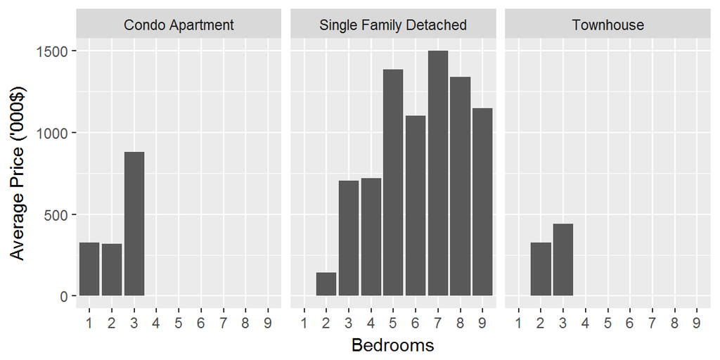

```r
ggplot(part_2, aes(x = factor(bedrooms), y = avgPrice/1000)) + xlab("Bedrooms") + ylab("Average Price ('000$)") +
  geom_bar(stat= "identity", position = "dodge") + facet_wrap(~subtype)
```

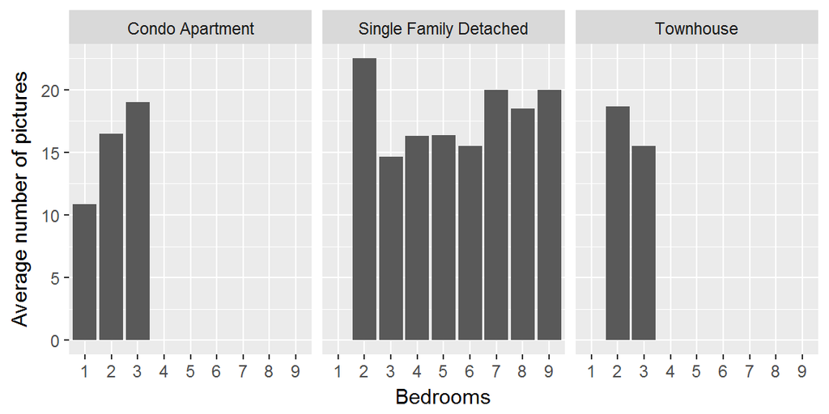

```r
ggplot(part_2, aes(x = factor(bedrooms), y = npics)) + xlab("Bedrooms") + ylab("Average number of pictures") +
  geom_bar(stat= "identity", position = "dodge") + facet_wrap(~subtype)
```

In terms of the housing market,

1. Out of the 61 houses on Homezilla, nearly 20% (11) are 3-bedroom single-family detached houses. Following this are 2-bedroom condos and 5-bedroom family houses.
2. Looking at customer demand, 3-bedroom single-family houses get maximum traffic on HomeZilla, followed by 2-bedroom condos. These two are the biggest segments Homezilla should focus on.
3. Also, 2-bedroom townhouses have 150 customers viewing the property, making it the fourth most demanded house-type. However, only 3 such houses are posted on HomeZilla. This may be a segment to focus on.
4. In terms of average prices, single-family detached houses cost less than condos for the same number of bedrooms (see figure). Prices increase with the number of bedrooms, as expected.

From the above analysis, we can also talk about the supply of pictures on the HomeZilla website. 1. When we look at the number of pictures, we find that number of pictures roughly increases with the number of bedrooms. However, there are 14.6 pictures for a 3-bedroom family house (the most popular segment), and 16.5 pictures for a 2-bedroom condo. 2. We also note that 2-bedroom townhouses have a higher number of pictures (18.67) than the top 3 segments. This represents an opportunity for HomeZilla to increase its pictures for the 3-bedroom family houses, 2-bedroom condos and 5-bedroom family houses to provide more information to potential buyers about the properties.

We can also analyze which properties customers spend more time on. This would help us give more nuanced suggestions to HomeZilla. Here, we get the total time spent and number of pictures viewed for every customer and property in the browsing dataset, and merge with the properties dataset. We then look at the number of pictures, average pictures viewed and average time spent for each subtype and number of bedrooms.

```r
collapsed_browsing = browsing %>%
  group_by(`Web ID`, `Customer ID`) %>%
  summarize(time = sum(`Time Viewed`), NumPicsViewed = n_distinct(`Photo ID`)) %>%
  ungroup()

df_cleaned = inner_join(collapsed_browsing, properties)

part_3 = df_cleaned %>%
  group_by(subtype, bedrooms) %>%
  summarize(NumCustomers = n_distinct(`Customer ID`), AvgTime = mean(time),
            AvgPicsViewed = mean(NumPicsViewed), AvgTimePerPic = mean(time/NumPicsViewed))
part_3
```

```
## # A tibble: 13 x 6
## # Groups: subtype [?]
##    subtype                bedrooms NumCustomers AvgTime AvgPicsV~ AvgTime~
##    <chr>                     <dbl>        <int>   <dbl>     <dbl>    <dbl>
##  1 Condo Apartment            1.00          127    97.1      8.25     16.4
##  2 Condo Apartment            2.00          326   554       11.6      45.5
##  3 Condo Apartment            3.00           29   212       10.8      25.0
##  4 Single Family Detached     2.00           45   177       15.0      13.0
##  5 Single Family Detached     3.00          473   670       10.7      94.0
##  6 Single Family Detached     4.00          100   170       10.4      28.9
##  7 Single Family Detached     5.00          190   678       14.0      63.2
##  8 Single Family Detached     6.00           87  1060       14.1      97.2
##  9 Single Family Detached     7.00            5   477       18.8      24.1
## 10 Single Family Detached     8.00           24  1022       13.2      62.5
## 11 Single Family Detached     9.00            4  2580       20.0     129
## 12 Townhouse                  2.00          149  3999       14.3     238
## 13 Townhouse                  3.00          105   622       13.4      68.3
```

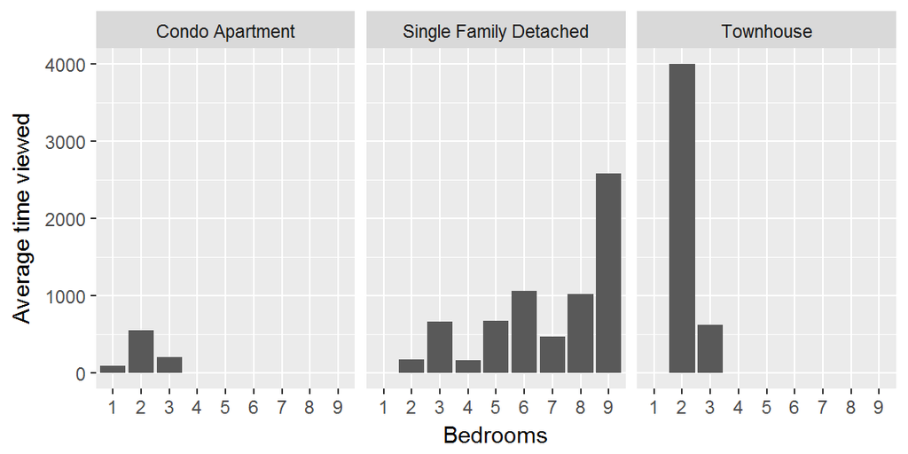

```r
ggplot(part_3, aes(x = factor(bedrooms), y = AvgTime)) + xlab("Bedrooms") + ylab("Average time viewed") +
  geom_bar(stat= "identity", position = "dodge") + facet_wrap(~subtype)
```

First, we note that average time viewed increases with the number of bedrooms. Second, there seem to be anomalies in the data due to outliers since 2-bedroom townhouses are viewed on average for 4000 seconds (which is more than an hour). This indicates the need for more precise data measurement. However, given the present data, we can say that customers view 3-bedroom family houses on average for 11 minutes, and particularly 94 seconds per picture. This is a high level of customer engagement, which represents high intent to purchase. There is a similar increase for 6-bedroom family houses, but not a significant lift for 2-bedroom condos or 5-bedroom family houses which are the second and third-biggest customer segments. We would again recommend HomeZilla to provide more or better pictures which increases customer engagment for these key segments.

To define which are “better” pictures, we use the photo-tag classification from the browsing data, and see which pictures customers spend more time on. Here, we re-do the previous analysis with an additional `Photo Tag 1` variable.

```r
agg_browsing = browsing %>%
  group_by(`Web ID`,`Photo Tag 1`) %>%
  summarize(npics_bytag = n_distinct(`Photo ID`))

#### Merge properties and aggregate browsing
part_4 = merge(properties, agg_browsing, by= "Web ID")
#### Housing Market
part_4a= part_4 %>%
  group_by(subtype, bedrooms, `Photo Tag 1`) %>%
  summarize(npics = mean(npics_bytag)) %>%
  spread(`Photo Tag 1`, npics)
part_4a
```

```
## # A tibble: 13 x 5
## # Groups: subtype, bedrooms [13]
##    subtype                bedrooms exterior floor interior
##  * <chr>                     <dbl>    <dbl> <dbl>    <dbl>
##  1 Condo Apartment            1.00     2.83 NA        8.00
##  2 Condo Apartment            2.00     3.25  1.00    12.9
##  3 Condo Apartment            3.00     4.00  1.00    14.5
##  4 Single Family Detached     2.00    10.0  NA       12.5
##  5 Single Family Detached     3.00     3.09  1.00    11.4
##  6 Single Family Detached     4.00     3.14 NA       13.1
##  7 Single Family Detached     5.00     3.38 NA       13.0
##  8 Single Family Detached     6.00     3.75  1.00    11.2
##  9 Single Family Detached     7.00     4.00 NA       16.0
## 10 Single Family Detached     8.00     3.00 NA       15.5
## 11 Single Family Detached     9.00     2.00 NA       18.0
## 12 Townhouse                  2.00     6.67 NA       12.0
## 13 Townhouse                  3.00     3.83 NA       11.7
```

Here, looking at the supply of pictures, there are approximately 12-13 pictures for 2-bedroom house interiors (both condo and single-family. Comparing 3-bedroom single-family and condos, the former only has 11.36 pictures for the interior (less than a 2-bedroom single family) vis-a-vis 14.5 pictures for the latter. This is a big discrepancy in the supply of pictures which should be rectified. Similarly, although interior pictures should increase with the number of bedrooms, 6-bedroom family houses have only 11.25 pictures compared to 5-bedroom houses. Again, we would strongly recommend to increase the supply of pictures for these properties.

Next, we look at the time spent by photo tag.

```r
collapsed_browsing = browsing %>%
  group_by(`Web ID`, `Customer ID`,`Photo Tag 1`) %>%
  summarize(time = sum(`Time Viewed`), NumPicsViewed = n_distinct(`Photo ID`)) %>%
  ungroup()

df_cleaned = inner_join(collapsed_browsing, properties)
part_4b = df_cleaned %>%
  group_by(subtype, bedrooms, `Photo Tag 1`) %>%
  summarize(AvgTimePerPic = mean(time/NumPicsViewed)) %>%
  spread(`Photo Tag 1`, AvgTimePerPic)
part_4b
```

```
## # A tibble: 13 x 5
## # Groups: subtype, bedrooms [13]
##    subtype                bedrooms exterior  floor interior
##  * <chr>                     <dbl>    <dbl>  <dbl>    <dbl>
##  1 Condo Apartment            1.00     4.55   NA      18.8
##  2 Condo Apartment            2.00    56.7    35.0    52.3
##  3 Condo Apartment            3.00    19.8    51.8    17.5
##  4 Single Family Detached     2.00    17.3    NA       9.80
##  5 Single Family Detached     3.00   174    1038      77.9
##  6 Single Family Detached     4.00    31.7    NA      23.8
##  7 Single Family Detached     5.00   169      NA      60.6
##  8 Single Family Detached     6.00   189      16.8    80.6
##  9 Single Family Detached     7.00    29.5    NA      24.0
## 10 Single Family Detached     8.00   328      NA      22.8
## 11 Single Family Detached     9.00   621      NA      74.3
## 12 Townhouse                  2.00   206      NA     267
## 13 Townhouse                  3.00   147      NA      35.0
```

There are many interesting patterns to note here. First, for the most demanded segment of 3-bedroom family houses, customers spend a lot more time per pic on the exterior compared to the interior. This probably indicates they are looking whether the property has a yard, and how it looks on the exterior. Compared to that, customers almost spend equal time between the exterior and interior for a 2-bedroom condo. This pattern of spending more time on exterior pictures is consistent across single-family houses. Since we recommend increasing the total number of pictures for 3-bedroom houses, we also recommend providing more exterior pictures for the same.

In conclusion, after analyzing HomeZilla data, we have 3 recommendations for the company -

1. Providing more 2-bedroom townhouse properties given this is the 4th largest demanded segment, and cost similar to a 2-bedroom condo.
2. Compared to 2-bedroom townhouses, which have 18.67 pictures per property, the three larger segments have fewer pictures. We recommend to increase the total supply of pictures for 3-bedroom family houses, 2-bedroom condos, and 5-bedroom family houses.
3. 3-bedroom single family houses are the most demanded house-type, as well as the most supplied. This is a segment HomeZilla should focus a lot on. We found that the number of pictures provided for this segment are lower than condos with similar (even lower!) number of bedrooms. Second, customers spend a lot of time (94 seconds per picture) for these properties, indicating a high degree of engagement. Also, they spend more time on exterior pictures than the interior. Given these takeaways, we strongly recommend HomeZilla to provide more exterior pictures for 3-bedroom family houses.